# Mixed-Design ANOVA Analysis

by Borja, Rachelle Erika

# Introduction

This study examined whether dating preferences were influenced by:

- Gender (Male vs Female)
- Looks (Attractive, Average, Ugly)
- Personality (High Charisma, Some Charisma, No Charisma)

A mixed-design ANOVA was conducted to determine whether there was a three-way interaction among gender, looks, and personality on dating ratings.

# Load Required Libraries

```r
library(haven)
library(tidyverse)
library(afex)
library(emmeans)
library(rstatix)
library(ggplot2)
library(car)
```

# Import Dataset

```r
data <- read_sav("Looksorpersonality.sav")

head(data)
```

```
## # A tibble: 6 × 10
##   Gender    att_high av_high ug_high att_some av_some ug_some att_none av_none
##   <dbl+lbl>    <dbl>   <dbl>   <dbl>    <dbl>   <dbl>   <dbl>    <dbl>   <dbl>
## 1 1 [Male]        86      84      67       88      69      50       97      48
## 2 1 [Male]        91      83      53       83      74      48       86      50
## 3 1 [Male]        89      88      48       99      70      48       90      45
## 4 1 [Male]        89      69      58       86      77      40       87      47
## 5 1 [Male]        80      81      57       88      71      50       82      50
## 6 1 [Male]        80      84      51       96      63      42       92      48
## # ℹ 1 more variable: ug_none <dbl>
```

# Convert Data to Long Format

```r
long_data <- data %>%

  mutate(

    Subject = factor(1:n()),

    Gender = as.factor(Gender)

  ) %>%

  pivot_longer(

    cols = att_high:ug_none,

    names_to = "Condition",

    values_to = "Rating"

  )
```

# Create Looks and Personality Variables

```r
long_data <- long_data %>%

  mutate(

    Looks = case_when(
      str_detect(Condition, "att") ~ "Attractive",
      str_detect(Condition, "av") ~ "Average",
      str_detect(Condition, "ug") ~ "Ugly"
    ),

    Personality = case_when(
      str_detect(Condition, "high") ~ "High Charisma",
      str_detect(Condition, "some") ~ "Some Charisma",
      str_detect(Condition, "none") ~ "No Charisma"
    )

  )

long_data$Looks <- factor(
  long_data$Looks,
  levels = c("Attractive", "Average", "Ugly")
)

long_data$Personality <- factor(
  long_data$Personality,
  levels = c(
    "High Charisma",
    "Some Charisma",
    "No Charisma"
  )
)

long_data <- na.omit(long_data)

head(long_data)
```

```
## # A tibble: 6 × 6
##   Gender Subject Condition Rating Looks      Personality
##   <fct>  <fct>   <chr>      <dbl> <fct>      <fct>
## 1 1      1       att_high      86 Attractive High Charisma
## 2 1      1       av_high       84 Average    High Charisma
## 3 1      1       ug_high       67 Ugly       High Charisma
## 4 1      1       att_some      88 Attractive Some Charisma
## 5 1      1       av_some       69 Average    Some Charisma
## 6 1      1       ug_some       50 Ugly       Some Charisma
```

# Descriptive Statistics

```r
descriptive_stats <- long_data %>%

  group_by(Gender, Looks, Personality) %>%

  summarise(

    Mean = round(mean(Rating), 3),

    SD = round(sd(Rating), 3),

    .groups = "drop"

  )

descriptive_stats
```

```
## # A tibble: 18 × 5
##    Gender Looks      Personality    Mean    SD
##    <fct>  <fct>      <fct>         <dbl> <dbl>
##  1 1      Attractive High Charisma  88.3  5.70
##  2 1      Attractive Some Charisma  88.5  5.74
##  3 1      Attractive No Charisma    87.3  5.44
##  4 1      Average    High Charisma  82.8  7.00
##  5 1      Average    Some Charisma  71.8  4.42
##  6 1      Average    No Charisma    47.8  4.18
##  7 1      Ugly       High Charisma  56.8  5.73
##  8 1      Ugly       Some Charisma  48.3  5.38
##  9 1      Ugly       No Charisma    45.8  3.58
## 10 2      Attractive High Charisma  89.6  6.64
## 11 2      Attractive Some Charisma  87.1  6.81
## 12 2      Attractive No Charisma    51.8  3.46
## 13 2      Average    High Charisma  88.4  8.33
## 14 2      Average    Some Charisma  68.9  5.95
## 15 2      Average    No Charisma    47    3.74
## 16 2      Ugly       High Charisma  86.7  5.44
## 17 2      Ugly       Some Charisma  51.2  5.45
## 18 2      Ugly       No Charisma    46.1  3.07
```

# Mixed-Design ANOVA

```r
anova_results <- aov_car(

  Rating ~ Gender * Looks * Personality +

    Error(Subject/(Looks * Personality)),

  data = long_data,

  factorize = FALSE

)

anova_results
```

```
## Anova Table (Type 3 tests)
##
## Response: Rating
##                     Effect          df   MSE          F   ges p.value
## 1                   Gender       1, 18 42.23       0.00 <.001    .946
## 2                    Looks 1.92, 34.62 25.50 423.73 ***  .809   <.001
## 3             Gender:Looks 1.92, 34.62 25.50  80.43 ***  .445   <.001
## 4              Personality 1.87, 33.62 37.89 328.25 ***  .826   <.001
## 5       Gender:Personality 1.87, 33.62 37.89  62.45 ***  .474   <.001
## 6        Looks:Personality 3.20, 57.55 34.62  36.63 ***  .452   <.001
## 7 Gender:Looks:Personality 3.20, 57.55 34.62  24.12 ***  .352   <.001
## ---
## Signif. codes:  0 '***' 0.001 '**' 0.01 '*' 0.05 '+' 0.1 ' ' 1
##
## Sphericity correction method: GG
```

# ANOVA Table

```r
nice(anova_results, es = "pes")
```

```
## Anova Table (Type 3 tests)
##
## Response: Rating
##                     Effect          df   MSE          F   pes p.value
## 1                   Gender       1, 18 42.23       0.00 <.001    .946
## 2                    Looks 1.92, 34.62 25.50 423.73 ***  .959   <.001
## 3             Gender:Looks 1.92, 34.62 25.50  80.43 ***  .817   <.001
## 4              Personality 1.87, 33.62 37.89 328.25 ***  .948   <.001
## 5       Gender:Personality 1.87, 33.62 37.89  62.45 ***  .776   <.001
## 6        Looks:Personality 3.20, 57.55 34.62  36.63 ***  .671   <.001
## 7 Gender:Looks:Personality 3.20, 57.55 34.62  24.12 ***  .573   <.001
## ---
## Signif. codes:  0 '***' 0.001 '**' 0.01 '*' 0.05 '+' 0.1 ' ' 1
##
## Sphericity correction method: GG
```

# Assumption Checks

## Normality of Residuals

```r
residuals_data <- residuals(anova_results$lm)

shapiro.test(residuals_data)
```

```
##
##  Shapiro-Wilk normality test
##
## data:  residuals_data
## W = 0.98248, p-value = 0.02329
```

### Interpretation

- If p > .05, the residuals are approximately normally distributed.
- If p < .05, the residuals are not normally distributed.

# Homogeneity of Variance

```r
leveneTest(

  Rating ~ Gender * Looks * Personality,

  data = long_data

)
```

```
## Levene's Test for Homogeneity of Variance (center = median)
##        Df F value Pr(>F)
## group  17  0.8991  0.576
##       162
```

### Interpretation

- If p > .05, homogeneity of variance is satisfied.
- If p < .05, homogeneity of variance is violated.

# Estimated Marginal Means

```r
emmeans(

  anova_results,

  pairwise ~ Looks * Personality | Gender

)
```

```
## $emmeans
## Gender = 1:
##  Looks      Personality   emmean   SE df lower.CL upper.CL
##  Attractive High.Charisma   88.3 1.96 18     84.2     92.4
##  Average    High.Charisma   82.8 2.43 18     77.7     87.9
##  Ugly       High.Charisma   56.8 1.77 18     53.1     60.5
##  Attractive Some.Charisma   88.5 1.99 18     84.3     92.7
##  Average    Some.Charisma   71.8 1.66 18     68.3     75.3
##  Ugly       Some.Charisma   48.3 1.71 18     44.7     51.9
##  Attractive No.Charisma     87.3 1.44 18     84.3     90.3
##  Average    No.Charisma     47.8 1.26 18     45.2     50.4
##  Ugly       No.Charisma     45.8 1.06 18     43.6     48.0
##
## Gender = 2:
##  Looks      Personality   emmean   SE df lower.CL upper.CL
##  Attractive High.Charisma   89.6 1.96 18     85.5     93.7
##  Average    High.Charisma   88.4 2.43 18     83.3     93.5
##  Ugly       High.Charisma   86.7 1.77 18     83.0     90.4
##  Attractive Some.Charisma   87.1 1.99 18     82.9     91.3
##  Average    Some.Charisma   68.9 1.66 18     65.4     72.4
##  Ugly       Some.Charisma   51.2 1.71 18     47.6     54.8
##  Attractive No.Charisma     51.8 1.44 18     48.8     54.8
##  Average    No.Charisma     47.0 1.26 18     44.4     49.6
##  Ugly       No.Charisma     46.1 1.06 18     43.9     48.3
##
## Confidence level used: 0.95
##
## $contrasts
## Gender = 1:
##  contrast                                            estimate   SE df t.ratio
##  Attractive High.Charisma - Average High.Charisma         5.5 2.83 18   1.946
##  Attractive High.Charisma - Ugly High.Charisma           31.5 2.17 18  14.535
##  Attractive High.Charisma - Attractive Some.Charisma     -0.2 2.93 18  -0.068
##  Attractive High.Charisma - Average Some.Charisma        16.5 1.93 18   8.561
##  Attractive High.Charisma - Ugly Some.Charisma           40.0 2.36 18  16.950
##  Attractive High.Charisma - Attractive No.Charisma        1.0 2.63 18   0.380
##  Attractive High.Charisma - Average No.Charisma          40.5 2.14 18  18.896
##  Attractive High.Charisma - Ugly No.Charisma             42.5 2.04 18  20.835
##  Average High.Charisma - Ugly High.Charisma              26.0 2.75 18   9.459
##  Average High.Charisma - Attractive Some.Charisma        -5.7 3.51 18  -1.624
```

[output cut: 126 more lines]

```
##  <0.0001
##  <0.0001
##  <0.0001
##  <0.0001
##  <0.0001
##  <0.0001
##  <0.0001
##   1.0000
##   0.6276
##   0.3304
##   0.1495
##   0.0713
##   0.9997
##
## P value adjustment: tukey method for comparing a family of 9 estimates
```

# Interaction Plot

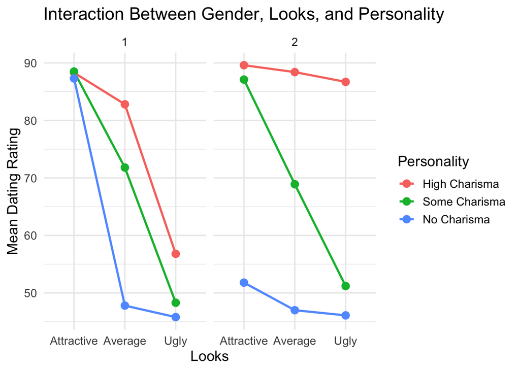

```r
means_data <- long_data %>%

  group_by(Gender, Looks, Personality) %>%

  summarise(

    Mean = mean(Rating),

    .groups = "drop"

  )

ggplot(

  means_data,

  aes(

    x = Looks,

    y = Mean,

    color = Personality,

    group = Personality

  )

) +

  geom_line(linewidth = 1) +

  geom_point(size = 3) +

  facet_wrap(~Gender) +

  labs(

    title = "Interaction Between Gender, Looks, and Personality",

    x = "Looks",

    y = "Mean Dating Rating"

  ) +

  theme_minimal(base_size = 14)
```

# Interpretation of Results

## Three-Way Interaction

The mixed-design ANOVA revealed a significant three-way interaction between gender, looks, and personality.

This indicates that the combined effects of attractiveness and charisma on dating ratings differed between males and females.

Specifically:

- Personality influenced dating ratings differently across attractiveness conditions.
- High charisma generally increased dating ratings.
- Personality appeared to compensate for lower physical attractiveness.
- The strength of these effects differed between genders.

# Significant Two-Way Interactions

## Gender × Looks

This interaction suggests that males and females evaluated physical attractiveness differently.

## Gender × Personality

This interaction indicates that charisma affected dating ratings differently depending on gender.

## Looks × Personality

This interaction suggests that personality influenced dating ratings differently across attractiveness levels.

# Main Effects

## Gender

The main effect of gender examines whether males and females differed overall in dating ratings.

## Looks

The main effect of looks examines whether attractiveness influenced dating ratings overall.

## Personality

The main effect of personality examines whether charisma influenced dating ratings overall.

# Overall Conclusion

The mixed-design ANOVA demonstrated that dating preferences were influenced by a combination of gender, physical attractiveness, and personality.

Overall, the personality had a strong influence on dating ratings.High charisma substantially improved dating evaluations. Personality compensated for lower physical attractiveness. The influence of attractiveness and personality differed between males and females.